# ISE201 - Final Project

Teja Sree Goli

2023-12-04

## Introduction

The title of the dataset chosen is “Sustainability Development Report - 2023”. The dataset comprises comprehensive data related to sustainability and progress towards Sustainable Development Goals (SDGs) for numerous countries. I am curious to know “How has each country progressed towards achieving these Sustainable Development Goals (SDGs) over time, considering the impact of economic and geopolitical factors?”

Understanding the progress made by each country towards achieving the SDGs is crucial for assessing the effectiveness of global sustainability efforts and identifying areas of improvement to make improved future decision-making.

Analyzing each individual country’s progress helps in: holding the countries accountable and enhancing global collaboration.

## Data Source

Sazidul Islam. “Sustainability Development Report”. kaggle.com  
https://www.kaggle.com/datasets/sazidthe1/sustainable-development-report (accessed Oct 1, 2023).

Original Source: https://sdgtransformationcenter.org/reports/sustainable-development-report-2023

## Data Collection

The Sustainable Development Report (SDR), sourced from Kaggle, reviews the progress made by countries each year on the Sustainable Development Goals since their adoption by the 193 UN Member States. The Sustainable Development Report 2023 takes stock of progress made (an observational study – it is an annual report – a global study). The report was published on the eve of the 2023 Paris Summit for a New Global Financial Pact.

## Cases - Units of Observations

The report provides SDGs of 167 countries across the world. Each entry in the dataset presents information on a country’s sustainability scores, regional classification, and performance on individual SDGs.

## Variables

There are total 21 variables in this dataset. For the purpose of this analysis, we focus on a subset of variables:

country  
region  
overall_score  
scores of the 7 goals (poverty, education, health, climate, hunger, sustainable_cities, consumption_production) - goal_x_score

## Type of Study

The data collected is observed over a period of time for various factors. Hence, it is an observational study.

## Data Cleanup

```r
library(dplyr)
```

```r
library(ggplot2)
```

Let’s check for missing values and duplicated rows.

```r
sustainability_report <- read.csv("C:/Users/golit/OneDrive/Desktop/ISE 201/Project/sustainable_development_report_2023.csv")

sum(is.na(sustainability_report))
```

```
## [1] 72
```

```r
sum(duplicated(sustainability_report))
```

```
## [1] 0
```

There are 72 missing values and no duplicated observations.

```r
sustainability_report <- na.omit(sustainability_report)
head(sustainability_report)
```

```
##   country_code country region overall_score goal_1_score goal_2_score
## 1          FIN Finland   OECD      86.76059      99.5750     60.88675
## 2          SWE  Sweden   OECD      85.98140      98.8885     63.07413
## 3          DNK Denmark   OECD      85.68364      99.2155     71.02525
## 4          DEU Germany   OECD      83.35845      99.5105     72.36600
## 6          FRA  France   OECD      82.04834      99.7285     72.39012
## 7          NOR  Norway   OECD      82.00449      99.2225     60.79487
##   goal_3_score goal_4_score goal_5_score goal_6_score goal_7_score goal_8_score
## 1     95.38638     97.16933     92.11125      94.3276     93.01350     86.78900
## 2     96.90400     99.76167     91.44025      95.0576     97.97350     84.96643
## 3     95.39850     99.33967     86.99800      90.7316     87.73050     87.56243
## 4     93.03936     97.16267     81.92025      88.4434     77.16175     86.96729
## 6     93.22457     99.63000     87.82325      89.2696     78.61550     85.30600
## 7     97.11514     97.98733     92.87925      83.6618     98.53825     85.93243
##   goal_9_score goal_10_score goal_11_score goal_12_score goal_13_score
## 1     95.99571       98.4685      91.23375      60.05957      68.79367
## 2     97.58629       94.9650      90.38925      56.83057      70.03100
## 3     96.98486       98.1560      93.03850      44.57171      60.78067
## 4     95.78843       88.1470      90.09650      55.41286      64.00200
## 6     92.77586       87.4735      90.52950      60.51543      73.83467
## 7     92.44300       99.4060      91.16475      39.77529      20.68500
##   goal_14_score goal_15_score goal_16_score goal_17_score
## 1      87.92800       85.0700      92.52109      75.60100
## 2      69.34867       80.1882      88.50845      85.77025
## 3      76.30333       92.7924      93.84491      82.14800
## 4      73.99600       79.2318      89.45755      84.39025
## 6      65.67750       68.8246      76.09173      73.11150
## 7      74.57900       74.1232      91.74200      94.02650
```

The null values are omitted for this analysis.

Rename the goal_x_score columns accordingly for the easy understanding of analysis.

```r
names(sustainability_report) <- c("country_code", "country", "region", "SDG_index", "poverty", "hunger", "health", "quality_education", "gender_equality", "clean_water",  "clean_energy", "economic_growth", "insfrastructure", "reduced_inequality", "sustainable_cities", "consumption_production", "climate_action",  "aquatic_life", "land_life","justice_institutins", "partnerships")

names(sustainability_report)
```

```
##  [1] "country_code"           "country"                "region"
##  [4] "SDG_index"              "poverty"                "hunger"
##  [7] "health"                 "quality_education"      "gender_equality"
## [10] "clean_water"            "clean_energy"           "economic_growth"
## [13] "insfrastructure"        "reduced_inequality"     "sustainable_cities"
## [16] "consumption_production" "climate_action"         "aquatic_life"
## [19] "land_life"              "justice_institutins"    "partnerships"
```

To proceed with further analysis, we are considering only goal_x_scores

```r
sustainability_report <- sustainability_report %>% select(country, region, SDG_index, poverty, hunger, health, quality_education, sustainable_cities, consumption_production, climate_action)

head(sustainability_report)
```

```
##   country region SDG_index poverty   hunger   health quality_education
## 1 Finland   OECD  86.76059 99.5750 60.88675 95.38638          97.16933
## 2  Sweden   OECD  85.98140 98.8885 63.07413 96.90400          99.76167
## 3 Denmark   OECD  85.68364 99.2155 71.02525 95.39850          99.33967
## 4 Germany   OECD  83.35845 99.5105 72.36600 93.03936          97.16267
## 6  France   OECD  82.04834 99.7285 72.39012 93.22457          99.63000
## 7  Norway   OECD  82.00449 99.2225 60.79487 97.11514          97.98733
##   sustainable_cities consumption_production climate_action
## 1           91.23375               60.05957       68.79367
## 2           90.38925               56.83057       70.03100
## 3           93.03850               44.57171       60.78067
## 4           90.09650               55.41286       64.00200
## 6           90.52950               60.51543       73.83467
## 7           91.16475               39.77529       20.68500
```

## Exploratory Data Analysis

To proceed with EDA, let’s visualize the correlation between various input variables and the overall sustainability score (SDG_index).

## Visualization

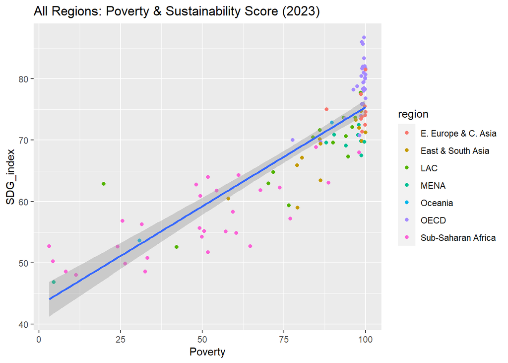

```r
ggplot(sustainability_report, aes(x=poverty, y=SDG_index)) +
  geom_point(aes(color = region)) +
  geom_smooth(method="lm") +
  xlab("Poverty") +
  ylab("SDG_index") +
  labs(colour="region") +
  ggtitle("All Regions: Poverty & Sustainability Score (2023)")
```

```r
cor(sustainability_report$poverty,sustainability_report$SDG_index)
```

```
## [1] 0.8726533
```

There is a high positive correlation between the poverty and sustainability scores indicating that poverty score has an impact on the overall growth of the countries.

```r
# Summary statistics
summary(sustainability_report[, c("SDG_index", "poverty")])
```

```
##    SDG_index        poverty
##  Min.   :46.85   Min.   :  3.155
##  1st Qu.:61.81   1st Qu.: 62.917
##  Median :70.43   Median : 93.959
##  Mean   :68.64   Mean   : 79.131
##  3rd Qu.:76.36   3rd Qu.: 98.999
##  Max.   :86.76   Max.   :100.000
```

```r
# Summary
summary(sustainability_report$SDG_index)
```

```
##    Min. 1st Qu.  Median    Mean 3rd Qu.    Max.
##   46.85   61.81   70.43   68.64   76.36   86.76
```

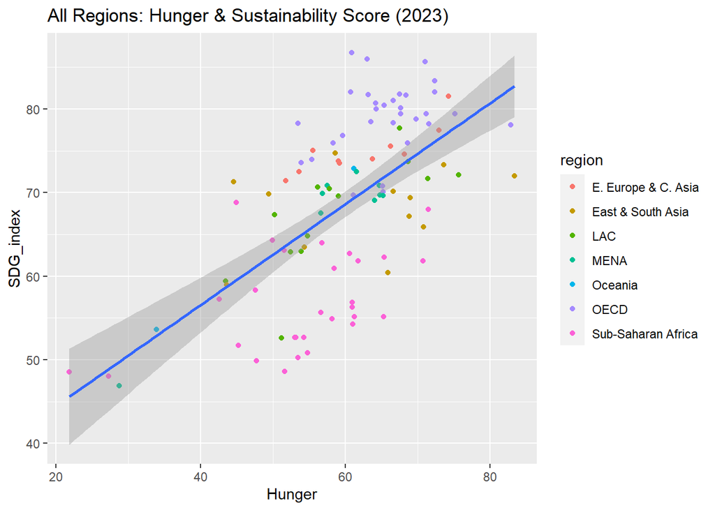

```r
ggplot(sustainability_report, aes(x= hunger, y=SDG_index)) +
  geom_point(aes(color = region)) +
  geom_smooth(method="lm") +
  xlab("Hunger") +
  ylab("SDG_index") +
  labs(colour="region") +
  ggtitle("All Regions: Hunger & Sustainability Score (2023)")
```

```r
cor(sustainability_report$hunger,sustainability_report$SDG_index)
```

```
## [1] 0.6271774
```

If not significant, Hunger still acts as an important attribute in the overall sustainability score of a country.

```r
# Summary statistics
summary(sustainability_report[, c("SDG_index", "hunger")])
```

```
##    SDG_index         hunger
##  Min.   :46.85   Min.   :21.90
##  1st Qu.:61.81   1st Qu.:54.11
##  Median :70.43   Median :61.07
##  Mean   :68.64   Mean   :60.06
##  3rd Qu.:76.36   3rd Qu.:67.53
##  Max.   :86.76   Max.   :83.40
```

```r
# Summary
summary(sustainability_report$SDG_index)
```

```
##    Min. 1st Qu.  Median    Mean 3rd Qu.    Max.
##   46.85   61.81   70.43   68.64   76.36   86.76
```

If not significant, Hunger still acts as an important attribute in the overall sustainability score of a country.

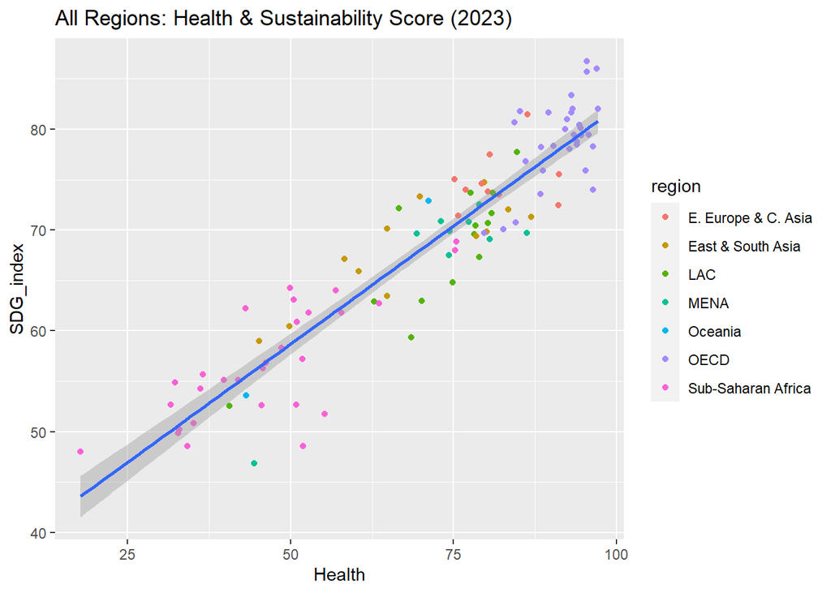

```r
ggplot(sustainability_report, aes(x=health, y=SDG_index)) +
  geom_point(aes(color = region)) +
  geom_smooth(method="lm") +
  xlab("Health") +
  ylab("SDG_index") +
  labs(colour="region") +
  ggtitle("All Regions: Health & Sustainability Score (2023)")
```

```r
cor(sustainability_report$health,sustainability_report$SDG_index)
```

```
## [1] 0.9300866
```

Health sector plays a very significant part in the overall growth of a country’s sustainability.

```r
# Summary statistics
summary(sustainability_report[, c("SDG_index", "health")])
```

```
##    SDG_index         health
##  Min.   :46.85   Min.   :17.86
##  1st Qu.:61.81   1st Qu.:52.37
##  Median :70.43   Median :77.65
##  Mean   :68.64   Mean   :71.20
##  3rd Qu.:76.36   3rd Qu.:87.59
##  Max.   :86.76   Max.   :97.12
```

```r
# Summary
summary(sustainability_report$SDG_index)
```

```
##    Min. 1st Qu.  Median    Mean 3rd Qu.    Max.
##   46.85   61.81   70.43   68.64   76.36   86.76
```

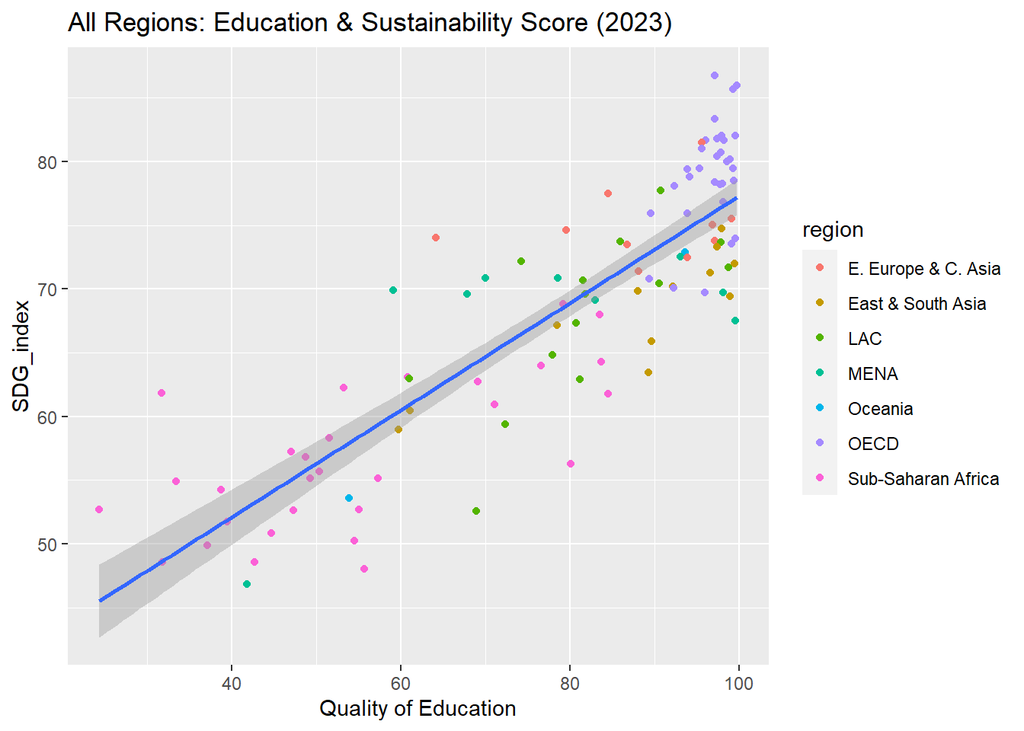

```r
ggplot(sustainability_report, aes(x=quality_education, y=SDG_index)) +
  geom_point(aes(color = region)) +
  geom_smooth(method="lm") +
  xlab("Quality of Education") +
  ylab("SDG_index") +
  labs(colour="region") +
  ggtitle("All Regions: Education & Sustainability Score (2023)")
```

```r
cor(sustainability_report$quality_education,sustainability_report$SDG_index)
```

```
## [1] 0.8593061
```

The quality of education provided in a country does have a high positive correlation with the overall sustainable development of that country.

```r
# Summary statistics
summary(sustainability_report[, c("SDG_index", "quality_education")])
```

```
##    SDG_index     quality_education
##  Min.   :46.85   Min.   :24.33
##  1st Qu.:61.81   1st Qu.:62.63
##  Median :70.43   Median :88.01
##  Mean   :68.64   Mean   :79.41
##  3rd Qu.:76.36   3rd Qu.:97.17
##  Max.   :86.76   Max.   :99.76
```

```r
# Summary
summary(sustainability_report$SDG_index)
```

```
##    Min. 1st Qu.  Median    Mean 3rd Qu.    Max.
##   46.85   61.81   70.43   68.64   76.36   86.76
```

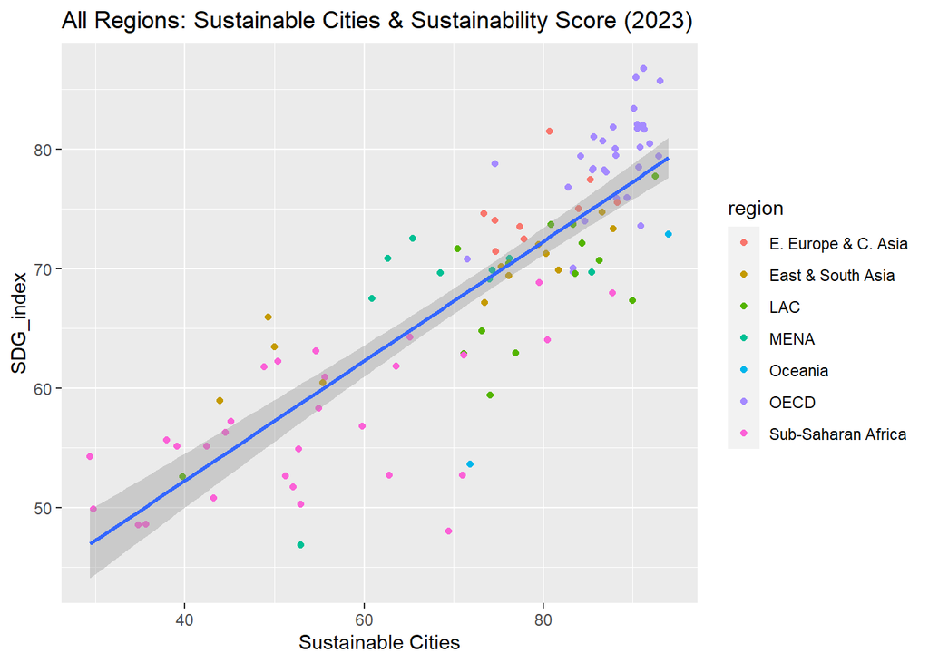

```r
ggplot(sustainability_report, aes(x=sustainable_cities, y=SDG_index)) +
  geom_point(aes(color = region)) +
  geom_smooth(method="lm") +
  xlab("Sustainable Cities") +
  ylab("SDG_index") +
  labs(colour="region") +
  ggtitle("All Regions: Sustainable Cities & Sustainability Score (2023)")
```

```r
cor(sustainability_report$sustainable_cities,sustainability_report$SDG_index)
```

```
## [1] 0.8449001
```

```r
# Summary statistics
summary(sustainability_report[, c("SDG_index", "sustainable_cities")])
```

```
##    SDG_index     sustainable_cities
##  Min.   :46.85   Min.   :29.44
##  1st Qu.:61.81   1st Qu.:61.78
##  Median :70.43   Median :76.90
##  Mean   :68.64   Mean   :72.74
##  3rd Qu.:76.36   3rd Qu.:86.63
##  Max.   :86.76   Max.   :93.98
```

```r
# Summary
summary(sustainability_report$SDG_index)
```

```
##    Min. 1st Qu.  Median    Mean 3rd Qu.    Max.
##   46.85   61.81   70.43   68.64   76.36   86.76
```

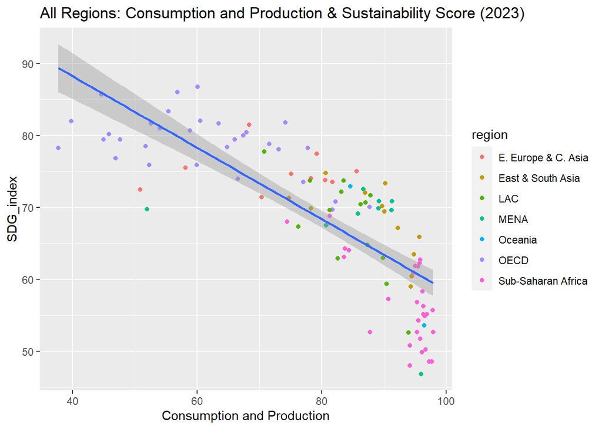

```r
ggplot(sustainability_report, aes(x=consumption_production, y=SDG_index)) +
  geom_point(aes(color = region)) +
  geom_smooth(method="lm") +
  xlab("Consumption and Production") +
  ylab("SDG_index") +
  labs(colour="region") +
  ggtitle("All Regions: Consumption and Production & Sustainability Score (2023)")
```

```r
cor(sustainability_report$consumption_production,sustainability_report$SDG_index)
```

```
## [1] -0.7906731
```

```r
# Summary statistics
summary(sustainability_report[, c("SDG_index", "consumption_production")])
```

```
##    SDG_index     consumption_production
##  Min.   :46.85   Min.   :37.73
##  1st Qu.:61.81   1st Qu.:69.35
##  Median :70.43   Median :83.61
##  Mean   :68.64   Mean   :79.45
##  3rd Qu.:76.36   3rd Qu.:94.14
##  Max.   :86.76   Max.   :97.89
```

```r
# Summary
summary(sustainability_report$SDG_index)
```

```
##    Min. 1st Qu.  Median    Mean 3rd Qu.    Max.
##   46.85   61.81   70.43   68.64   76.36   86.76
```

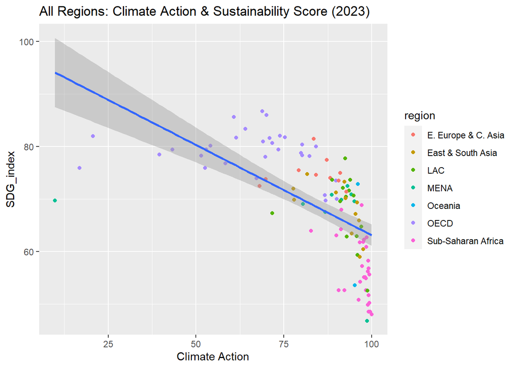

```r
ggplot(sustainability_report, aes(x=climate_action, y=SDG_index)) +
  geom_point(aes(color = region)) +
  geom_smooth(method="lm") +
  xlab("Climate Action") +
  ylab("SDG_index") +
  labs(colour="region") +
  ggtitle("All Regions: Climate Action & Sustainability Score (2023)")
```

```r
cor(sustainability_report$climate_action,sustainability_report$SDG_index)
```

```
## [1] -0.6108899
```

```r
# Summary statistics
summary(sustainability_report[, c("SDG_index", "climate_action")])
```

```
##    SDG_index     climate_action
##  Min.   :46.85   Min.   : 9.833
##  1st Qu.:61.81   1st Qu.:77.761
##  Median :70.43   Median :91.006
##  Mean   :68.64   Mean   :83.997
##  3rd Qu.:76.36   3rd Qu.:96.448
##  Max.   :86.76   Max.   :99.925
```

```r
# Summary
summary(sustainability_report$SDG_index)
```

```
##    Min. 1st Qu.  Median    Mean 3rd Qu.    Max.
##   46.85   61.81   70.43   68.64   76.36   86.76
```

## Principal Component Analysis

```r
#find principal components
sdg_pca <- sustainability_report %>%
select(poverty, hunger, health, quality_education, sustainable_cities, consumption_production, climate_action)
head(sdg_pca,3)
```

```
##   poverty   hunger   health quality_education sustainable_cities
## 1 99.5750 60.88675 95.38638          97.16933           91.23375
## 2 98.8885 63.07413 96.90400          99.76167           90.38925
## 3 99.2155 71.02525 95.39850          99.33967           93.03850
##   consumption_production climate_action
## 1               60.05957       68.79367
## 2               56.83057       70.03100
## 3               44.57171       60.78067
```

```r
#Find correlation matrix
corr_mat <- cor(sdg_pca)
corr_mat <- round(corr_mat, digits = 3)
corr_mat
```

```
##                        poverty hunger health quality_education
## poverty                  1.000  0.541  0.863             0.742
## hunger                   0.541  1.000  0.498             0.535
## health                   0.863  0.498  1.000             0.841
## quality_education        0.742  0.535  0.841             1.000
## sustainable_cities       0.717  0.425  0.847             0.769
## consumption_production  -0.644 -0.339 -0.801            -0.674
## climate_action          -0.515 -0.289 -0.658            -0.543
##                        sustainable_cities consumption_production climate_action
## poverty                             0.717                 -0.644         -0.515
## hunger                              0.425                 -0.339         -0.289
## health                              0.847                 -0.801         -0.658
## quality_education                   0.769                 -0.674         -0.543
## sustainable_cities                  1.000                 -0.721         -0.581
## consumption_production             -0.721                  1.000          0.863
## climate_action                     -0.581                  0.863          1.000
```

Extract the eigenvalues/variances of principal components

```r
eigen_value <- eigen(corr_mat)

# eigen values
(values <- eigen_value$values)
```

```
## [1] 4.90585391 0.88949238 0.52184652 0.27987574 0.21761305 0.11219940 0.07311901
```

Eigenvalues can be used to determine the number of principal components to retain after PCA.

```r
# eigen vector
(vector <- eigen_value$vectors)
```

```
##            [,1]        [,2]       [,3]         [,4]        [,5]        [,6]
## [1,] -0.3910714 -0.22009799 -0.2463675  0.760095963  0.03342353 -0.18787437
## [2,] -0.2665388 -0.69666666  0.6357333 -0.113616686  0.14704137  0.06744559
## [3,] -0.4310713 -0.01614388 -0.2237337  0.141917701  0.00526023  0.22665461
## [4,] -0.3977498 -0.16929324 -0.2347944 -0.403127455 -0.74437154 -0.11542709
## [5,] -0.3967099  0.01440941 -0.3580991 -0.473350515  0.64781137 -0.20453992
## [6,]  0.3941791 -0.40706352 -0.2130027 -0.006061406 -0.01152673 -0.72116862
## [7,]  0.3453072 -0.52094460 -0.5063160 -0.050946511  0.05790169  0.57752734
##             [,7]
## [1,] -0.35180009
## [2,]  0.01941544
## [3,]  0.83205743
## [4,] -0.16757785
## [5,] -0.16917983
## [6,]  0.33659799
## [7,] -0.11635207
```

```r
#Percent variance explained
pve <- values / sum(values)
pve
```

```
## [1] 0.70083627 0.12707034 0.07454950 0.03998225 0.03108758 0.01602849 0.01044557
```

```r
#Cumulative percent variance explained
cumsum(pve)
```

```
## [1] 0.7008363 0.8279066 0.9024561 0.9424384 0.9735259 0.9895544 1.0000000
```

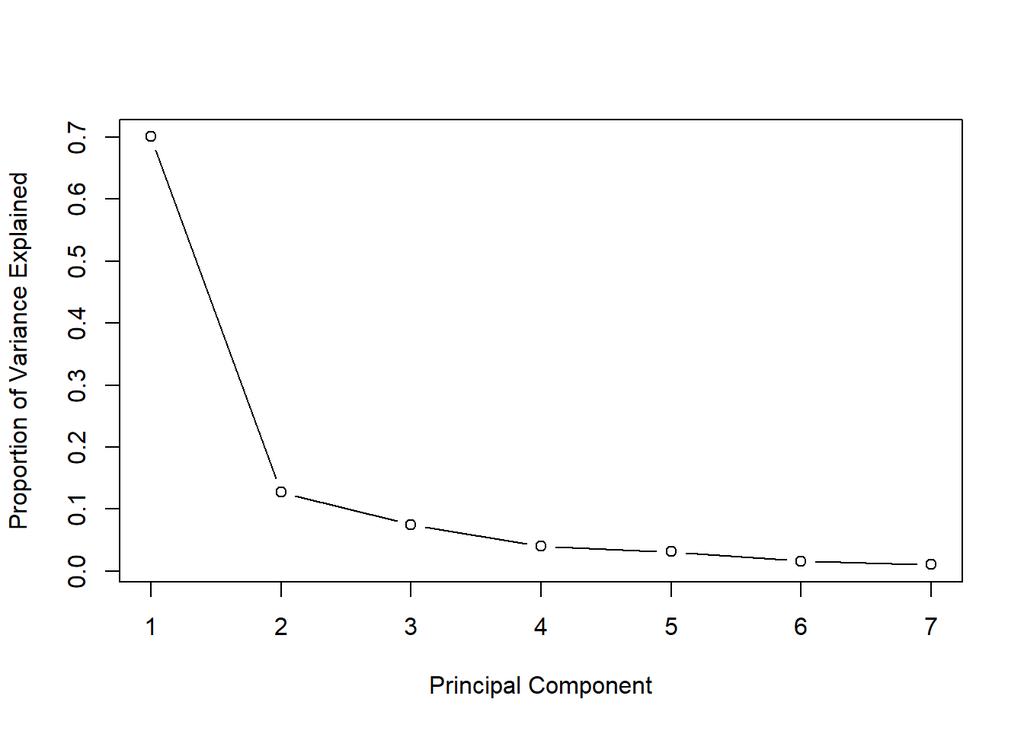

```r
plot(pve, xlab = "Principal Component",
     ylab = "Proportion of Variance Explained",
     type = "b")
```

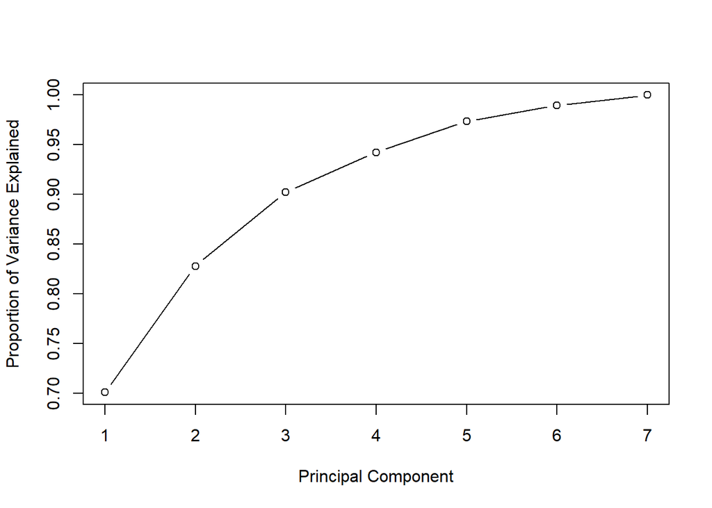

```r
plot(cumsum(pve), xlab = "Principal Component",
     ylab = "Proportion of Variance Explained",
     type = "b")
```

From the above calculations and charts, it can be said that the first three components explain ~90% of the variability in the data. Hence dimensions of the matrix can be reduced at the cost of remaining ~10% variability.

```r
eigen_vec = vector[,1:3]
colnames(eigen_vec) = c("e1", "e2", "e3")
row.names(eigen_vec) = colnames(sdg_pca)
eigen_vec
```

```
##                                e1          e2         e3
## poverty                -0.3910714 -0.22009799 -0.2463675
## hunger                 -0.2665388 -0.69666666  0.6357333
## health                 -0.4310713 -0.01614388 -0.2237337
## quality_education      -0.3977498 -0.16929324 -0.2347944
## sustainable_cities     -0.3967099  0.01440941 -0.3580991
## consumption_production  0.3941791 -0.40706352 -0.2130027
## climate_action          0.3453072 -0.52094460 -0.5063160
```

From the matrix above, health seems to dominate the first principal component with other features holding almost equal weight. Second principal components seems be dominated by hunger. Third component is also highly dominated by hunger followed by climate_action. Let’s find scaled principal components. We will use this later to perform multiple linear regression.

```r
PC1_t <- as.matrix(scale(sdg_pca)) %*% eigen_vec[,1]
PC2_t <- as.matrix(scale(sdg_pca)) %*% eigen_vec[,2]
PC3_t <- as.matrix(scale(sdg_pca)) %*% eigen_vec[,3]

PC_t  <- data.frame(PC1_t, PC2_t, PC3_t)
PC_t["Country"] <- sustainability_report["country"]

head(PC_t,3)
```

```
##       PC1_t     PC2_t      PC3_t Country
## 1 -2.355624 0.5584247 -0.3072226 Finland
## 2 -2.518276 0.4422849 -0.1902160  Sweden
## 3 -3.218773 0.4967705  0.6709810 Denmark
```

## Hypothesis Testing

Now that we have a better understanding of what factors are influencing the SDG_index score of a country, I would like to check on specific parameters [education and health] about their influence on SDG score.

## 1. Hypothesis Parameter - Education

*Null Hypothesis (H0):* There is no significant difference in SDG_index based on quality of education. [This hypothesis suggests that the average SDG_index is the same for countries with different levels of quality of education.]

*Alternative Hypothesis (H1):* There is a significant difference in SDG_index based on quality of education.

*Test Statistic:* Relation between SDG Index and Quality of Education using two-sample T-statistic. [The t-statistic is used to compare the mean SDG_index values for the two groups of countries: those with high quality of education and those with low quality of education.]

*Reference Distribution:* The t-distribution is used as the reference distribution for this test because the assumption of normality is not met.

*Rejection Criteria:* If the p-value is less than or equal to the significance level (0.05), we reject the null hypothesis (H₀) and conclude that there is a significant difference in SDG_index based on quality of education.

If the p-value is greater than the significance level, we fail to reject the null hypothesis (H₀) and conclude that there is not enough evidence to support the claim that there is a significant difference in SDG_index based on quality of education.

```r
# Two-sample t-test for the SDG index against quality education
t_test1 <- t.test(sustainability_report$SDG_index, sustainability_report$quality_education)
t_test1
```

```
##
##  Welch Two Sample t-test
##
## data:  sustainability_report$SDG_index and sustainability_report$quality_education
## t = -4.7993, df = 153.85, p-value = 3.737e-06
## alternative hypothesis: true difference in means is not equal to 0
## 95 percent confidence interval:
##  -15.196007  -6.333877
## sample estimates:
## mean of x mean of y
##  68.64102  79.40596
```

## 2. Hypothesis Parameter - Health

*Null Hypothesis (H0):* There is no significant difference in SDG_index based on quality of health care [This hypothesis suggests that the average SDG_index is the same for countries with different levels of quality of health care provided.]

*Alternative Hypothesis (H1):* There is a significant difference in SDG_index based on quality of health care

*Test Statistic:* Relation between SDG Index and Quality of Health care using two-sample T-statistic.

*Reference Distribution:* The t-distribution is used as the reference distribution for this test because the assumption of normality is not met.

*Rejection Criteria:* If the p-value is less than or equal to the significance level (0.05), we reject the null hypothesis (H₀) and conclude that there is a significant difference in SDG_index based on quality of health care.

If the p-value is greater than the significance level, we fail to reject the null hypothesis (H₀) and conclude that there is not enough evidence to support the claim that there is a significant difference in SDG_index based on quality of health care.

```r
# Two-sample t-test for the SDG index against health care
t_test2 <- t.test(sustainability_report$SDG_index, sustainability_report$health)
t_test2
```

```
##
##  Welch Two Sample t-test
##
## data:  sustainability_report$SDG_index and sustainability_report$health
## t = -1.1696, df = 156.72, p-value = 0.244
## alternative hypothesis: true difference in means is not equal to 0
## 95 percent confidence interval:
##  -6.86975  1.75993
## sample estimates:
## mean of x mean of y
##  68.64102  71.19593
```

## Multiple Regression

Our model has more than one predictor variable and one response and hence, we can use multiple regression model: Y =β0 + β1𝑋1 + β2𝑋2 + βk𝑋k + 𝜖

```r
model <- lm(sustainability_report$SDG_index~sustainability_report$poverty+sustainability_report$hunger+sustainability_report$health+sustainability_report$quality_education+sustainability_report$sustainable_cities+sustainability_report$consumption_production+sustainability_report$climate_action)

summary(model)
```

```
##
## Call:
## lm(formula = sustainability_report$SDG_index ~ sustainability_report$poverty +
##     sustainability_report$hunger + sustainability_report$health +
##     sustainability_report$quality_education + sustainability_report$sustainable_cities +
##     sustainability_report$consumption_production + sustainability_report$climate_action)
##
## Residuals:
##     Min      1Q  Median      3Q     Max
## -7.9864 -1.5253  0.2038  1.4507  7.8214
##
## Coefficients:
##                                              Estimate Std. Error t value
## (Intercept)                                  38.99527    3.53825  11.021
## sustainability_report$poverty                 0.08136    0.01813   4.488
## sustainability_report$hunger                  0.17307    0.02819   6.139
## sustainability_report$health                  0.12894    0.03800   3.393
## sustainability_report$quality_education       0.07040    0.02259   3.117
## sustainability_report$sustainable_cities      0.08722    0.02726   3.200
## sustainability_report$consumption_production -0.20107    0.03784  -5.314
## sustainability_report$climate_action          0.09135    0.02665   3.428
##                                              Pr(>|t|)
## (Intercept)                                   < 2e-16 ***
## sustainability_report$poverty                1.95e-05 ***
## sustainability_report$hunger                 1.73e-08 ***
## sustainability_report$health                 0.000995 ***
## sustainability_report$quality_education      0.002394 **
## sustainability_report$sustainable_cities     0.001847 **
## sustainability_report$consumption_production 6.62e-07 ***
## sustainability_report$climate_action         0.000887 ***
## ---
## Signif. codes:  0 '***' 0.001 '**' 0.01 '*' 0.05 '.' 0.1 ' ' 1
##
## Residual standard error: 2.485 on 99 degrees of freedom
## Multiple R-squared:  0.9444, Adjusted R-squared:  0.9404
## F-statistic:   240 on 7 and 99 DF,  p-value: < 2.2e-16
```

F-statistic is a good indicator of whether there is a relationship between our predictor and the response variables. The further the F-statistic is from 1 the better it is. In our example the F-statistic is 240 which is relatively larger than 1 given the size of our data.

It can also be seen that p-value is < 2.2e-16, which is highly significant. This means that, at least, one of the predictor variables is significantly related to the outcome variable. From the coefficients table, it seems that all features except quality_education and sustainable_cities are the most significant attributes.

‘R-squared’ is an important measures of how well our model predicts the desired response variable which is equal to 0.944 in our case. This value means that combination of poverty, hunger, health, quality_education, sustainable_cities, consumption_production and climate_action explain 94.4% of the variability in ‘SDG Index’.

Let’s also see if fitting a model based on PCA makes a difference since the dimension are reduced.

```r
pca_model <- lm(sustainability_report$SDG_index~PC1_t+PC2_t+PC3_t)
summary(pca_model)
```

```
##
## Call:
## lm(formula = sustainability_report$SDG_index ~ PC1_t + PC2_t +
##     PC3_t)
##
## Residuals:
##     Min      1Q  Median      3Q     Max
## -8.7635 -1.6593 -0.1194  1.9016  8.3808
##
## Coefficients:
##             Estimate Std. Error t value Pr(>|t|)
## (Intercept)  68.6410     0.2590 265.038  < 2e-16 ***
## PC1_t        -4.3770     0.1175 -37.258  < 2e-16 ***
## PC2_t        -1.5713     0.2760  -5.693 1.18e-07 ***
## PC3_t        -0.9950     0.3601  -2.763  0.00679 **
## ---
## Signif. codes:  0 '***' 0.001 '**' 0.01 '*' 0.05 '.' 0.1 ' ' 1
##
## Residual standard error: 2.679 on 103 degrees of freedom
## Multiple R-squared:  0.9327, Adjusted R-squared:  0.9308
## F-statistic: 476.1 on 3 and 103 DF,  p-value: < 2.2e-16
```

```r
confint(pca_model)
```

```
##                 2.5 %     97.5 %
## (Intercept) 68.127379 69.1546526
## PC1_t       -4.609973 -4.1439970
## PC2_t       -2.118652 -1.0238945
## PC3_t       -1.709241 -0.2807019
```

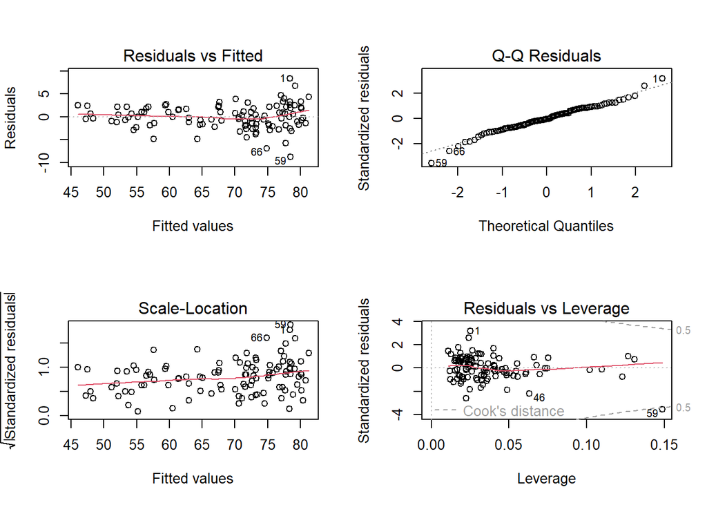

```r
par(mfrow = c(2,2))
plot(pca_model)
```

Graph 1 is called as fitted vs residual plot. The red line is quite flat. Hence linearity assumptions is met.

Graph 2 is known as QQ plot. The Y-axis is ordered, observed and standardized residuals. X-axis has ordered theoretical residuals. The points should fall roughly on the diagonal line and they do. Hence the assumption about the normal distribution of errors is also met.

Graph 3 and 4 also indicate linearity and almost constant variance.

# Conclusion: